# Enviromental data Exam

Name / Matricola

7 January 2025

# Preamble

## Instructions

**Please read the following carefully.**

- The exam is 120 minutes long.
- Only material on the course’s Moodle page may be used as a aid. You may not use your own annotations or other sources.
- Regarding the use of AI applications like ChatGPT and similar tools, please note that they are considered unauthorized aids.
- If a student attempts to influence the outcome of an examination by using unauthorized aids, the examination will be graded “unsatisfactory”. This determination will be made by the examiner, documented, and reported to the graduate program director, who is responsible for applying university regulations in such cases.

## Examination delivery

You edit the Rmarkdown file directly and submit the edited file via Moodle

Remember to **always** comment on your work. A solution with a simple list of commands will not be accepted.

# Exercise 1

The germination times of *Phaseolus vulgaris* (common bean) seeds are to be compared under three different soil moisture levels. Thirty seeds are tested at each moisture level (for a total of 90 seeds). Suppose the resulting data on germination times exhibits a **bimodal distribution**.

1. Define the experimental or observation units (i.e., sampling units) that might comprise the statistical population.
2. Determine the `type` of data represented (i.e., continuous, discrete, categorical, etc.).
3. Determine which are the dependent and independent variables (if any).
4. Determine what is the sample size.
5. Indicate whether the following strategies make sense for analyzing the data
   1. Perform a standard ANOVA test, assuming normality across the groups.
   2. Transform the data (e.g., logarithmic or square root transformation) to approximate normality, and then apply ANOVA.
   3. Use a non-parametric test, to compare the groups without assuming normality.
   4. Ignore the bimodal nature of the data and use a t-test for pairwise comparisons.
   5. Visualize the data using boxplots to better understand group differences after choosing a statistical test.

### a

Each of the individual common bean seed is the sampling unit.

### b

The germination times is continuous.

### c

- Dependent variables is germination times
- Independent variable is the moisture level

### d

The sample size is 90 seeds

### e

1. We can’t use ANOVA test because the data is bimodal and not normally distributed.
2. Yes we can, due to the transformation which makes the data normally distributed.
3. Kruskal wallis test can be used since it is the non-parametric counterpart of the ANOVA test.
4. You can’t use t-test because the data has three group levels.
5. Yes you can visualize the data using boxplots to better understand group differences after choosing a statistical test.

# Exercise 2

You are tasked with analyzing environmental data to investigate the impact of industrial activity on water quality.

The file `envdata-20250107-data1.csv` contains

1. `Temperature`: Daily average temperature (°C).
2. `Precipitation (mm)`: Daily precipitation levels (mm).
3. `IndustrialActivity`: Scale measuring industrial activity in the region categorized into groups.
4. `WaterpH`: Measure of water acidity/alkalinity
5. `NitrateLevels` Concentration of nitrates in water (mg/L).
6. `PhosphateLevels`: Concentration of phosphates in water (mg/L).

Questions

1. Load the dataset

```r
df1 <- read.csv("envdata-20250107data1.csv")
```

2. Display the first few rows and check the structure of the dataset.

```r
head(df1)
```

```
##   X Temperature Precipitation IndustrialActivity WaterpH NitrateLevels
## 1 1      31.166         7.350             Medium   7.179         8.557
## 2 2      32.168         2.718               High   7.636        13.187
## 3 3       2.876        16.571                Low   7.600         7.605
## 4 4      27.370         9.729                Low   7.662         6.121
## 5 5      18.879         9.210             Medium   7.330         8.926
## 6 6      13.359        24.239                Low   7.419         7.344
##   PhosphateLevels
## 1           0.512
## 2           0.902
## 3           4.130
## 4           2.344
## 5           2.368
## 6           3.466
```

```r
str(df1)
```

```
## 'data.frame':    300 obs. of  7 variables:
##  $ X                 : int  1 2 3 4 5 6 7 8 9 10 ...
##  $ Temperature       : num  31.17 32.17 2.88 27.37 18.88 ...
##  $ Precipitation     : num  7.35 2.72 16.57 9.73 9.21 ...
##  $ IndustrialActivity: chr  "Medium" "High" "Low" "Low" ...
##  $ WaterpH           : num  7.18 7.64 7.6 7.66 7.33 ...
##  $ NitrateLevels     : num  8.56 13.19 7.61 6.12 8.93 ...
##  $ PhosphateLevels   : num  0.512 0.902 4.13 2.344 2.368 ...
```

3. Select one variable for representing the water quality

```
WaterPH
```

4. Calculate summary statistics (mean, median, min, max, etc.) of the variable that you have selected grouped by industrial activity.

```r
ph_by_industry <- split(df1$WaterpH, df1$IndustrialActivity)
ph_by_industry
```

```
## $High
##  [1] 7.636 7.422 7.215 7.334 7.301 7.317 7.220 7.444 7.140 7.431 7.001 7.689
## [13] 7.482 7.488 7.687 7.256 7.111 7.269 7.290 7.635 7.594 7.627 6.961 7.606
## [25] 7.276 7.500 7.126 7.340 7.044 7.455 7.506 7.233 7.355 7.362 7.547 7.512
## [37] 7.409 7.300 7.249 7.513 7.541 7.229 7.469 7.182 7.895 7.568 7.313 7.259
## [49] 7.220 7.178 7.431 7.155 7.462 7.007 7.158 7.560 7.289 7.283 7.427 7.526
## [61] 7.040 7.743 7.067 7.325 7.247 7.643 7.342 7.690 7.399 7.532 7.206 7.115
## [73] 7.037 7.263 7.574 7.419 7.932 7.599 7.569 7.188 7.621 7.176 7.765 6.798
## [85] 8.018 7.400 7.846 7.058 7.524 7.658 7.208 7.101 7.238 7.311 7.498 7.633
##
## $Low
##   [1] 7.600 7.662 7.419 7.598 6.964 7.029 7.434 7.805 7.581 7.316 7.253 7.443
##  [13] 7.220 7.155 7.024 7.660 7.241 7.739 7.537 7.523 7.649 7.434 7.278 7.668
##  [25] 7.402 7.370 7.061 7.392 7.783 7.184 7.391 7.448 7.475 7.343 7.207 7.028
##  [37] 7.729 7.441 7.641 7.254 7.214 7.372 7.059 7.296 7.577 7.261 7.188 7.321
##  [49] 7.482 7.398 7.060 7.095 7.591 7.582 7.674 7.234 7.459 7.409 7.669 7.765
##  [61] 7.353 7.503 7.319 7.690 7.388 7.609 7.406 7.684 7.538 7.835 7.384 6.890
##  [73] 7.237 7.277 7.759 7.328 7.468 7.625 7.502 7.409 7.554 7.537 7.738 7.235
##  [85] 7.545 7.266 7.206 7.403 7.199 7.343 7.194 7.582 7.518 7.415 7.573 7.326
##  [97] 6.953 7.329 7.582 7.064 7.418 7.553 7.208 7.222 7.586 7.440 7.278 7.671
##
## $Medium
##  [1] 7.179 7.330 7.397 7.320 7.361 6.898 7.637 7.710 7.289 7.697 7.840 7.570
## [13] 7.347 6.983 7.458 7.349 7.010 7.564 7.026 7.759 7.512 7.413 7.278 7.583
## [25] 7.446 7.544 7.442 7.581 7.362 7.715 7.623 7.364 7.621 7.327 7.467 7.469
## [37] 7.254 7.406 7.175 7.556 7.341 7.658 7.373 7.353 7.498 7.462 6.874 7.158
## [49] 7.126 7.510 7.928 7.266 7.699 7.572 7.225 7.464 7.596 7.356 7.263 7.914
## [61] 7.281 7.229 7.527 7.520 7.350 7.560 7.833 7.165 7.284 7.586 7.488 7.888
## [73] 8.056 7.427 7.795 7.167 6.962 7.465 7.701 7.704 7.045 7.494 7.398 7.287
## [85] 7.260 7.508 7.176 7.320 6.838 6.880 7.503 7.688 7.547 7.374 7.555 7.062
```

```r
summary(df1)
```

```
##        X           Temperature      Precipitation    IndustrialActivity
##  Min.   :  1.00   Min.   :-9.9890   Min.   : 0.003   Length:300
##  1st Qu.: 75.75   1st Qu.: 0.3247   1st Qu.: 3.606   Class :character
##  Median :150.50   Median :12.2585   Median : 8.467   Mode  :character
##  Mean   :150.50   Mean   :12.2780   Mean   :10.621
##  3rd Qu.:225.25   3rd Qu.:23.5170   3rd Qu.:15.252
##  Max.   :300.00   Max.   :34.8450   Max.   :45.680
##     WaterpH      NitrateLevels    PhosphateLevels
##  Min.   :6.798   Min.   : 1.281   Min.   :0.0000
##  1st Qu.:7.252   1st Qu.: 6.989   1st Qu.:0.7422
##  Median :7.407   Median : 9.593   Median :1.6255
##  Mean   :7.405   Mean   : 9.799   Mean   :1.6270
##  3rd Qu.:7.569   3rd Qu.:12.832   3rd Qu.:2.3468
##  Max.   :8.056   Max.   :19.005   Max.   :5.3310
```

```r
sapply(ph_by_industry, summary)
```

```
##             High      Low   Medium
## Min.    6.798000 6.890000 6.838000
## 1st Qu. 7.220000 7.253750 7.280250
## Median  7.358500 7.409000 7.434500
## Mean    7.383521 7.409528 7.421052
## 3rd Qu. 7.542500 7.581250 7.570500
## Max.    8.018000 7.835000 8.056000
```

5. Comment the distributions of the variable across industrial activity categories.

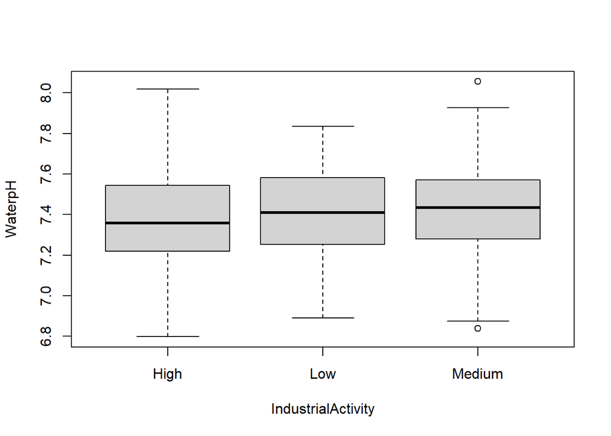

```r
boxplot(WaterpH ~ IndustrialActivity, data = df1)
```

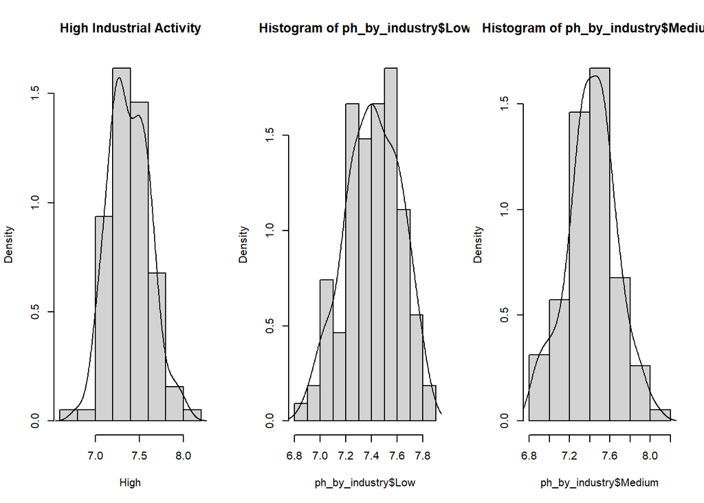

```r
par(mfrow = c(1,3))

# high
hist(ph_by_industry$High, prob = TRUE,
     main = "High Industrial Activity",
     xlab = "High")
lines(density(ph_by_industry$High))
# low
hist(ph_by_industry$Low, prob = TRUE)
lines(density(ph_by_industry$Low))
# medium
hist(ph_by_industry$Medium, prob = TRUE)
lines(density(ph_by_industry$Medium))
```

The industrial activity of medium is normally distributed compared to the other industrial activities.

6. Select one category of the industrial activity and discuss if the Gaussian distribution is an adequate model for interpreting the variability of the water quality

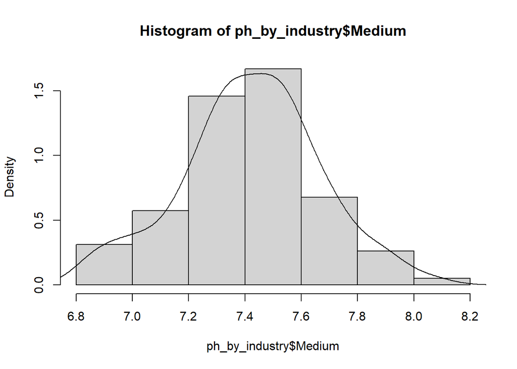

```r
hist(ph_by_industry$Medium, prob = TRUE)
lines(density(ph_by_industry$Medium))
```

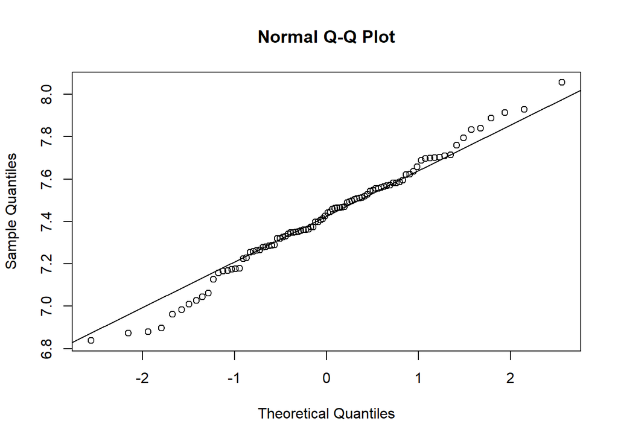

```r
qqnorm(ph_by_industry$Medium)
qqline(ph_by_industry$Medium)
```

Yes the category medium industrial activity follows a gaussian distribution due to the following reasons:

- The histogram and density potray a bell shaped.
- The points on the qqplot are approximately linear.

# Exercise 3

Mercury contamination of edible freshwater fish poses a direct threat to our health. Largemouth bass (fishes) were studied in 53 Florida lakes to examine the factors that influence the level of mercury contamination. Water samples were collected from the surface of the middle of each lake in August 1990 and then again in March 1991. The pH level, the amount of chlorophyll, calcium, and alkalinity were measured in each sample. The average of the August and March values were used in the analysis.

Next, a sample of fish was taken from each lake with sample sizes ranging from 4–44 fish, each used to measure a mercury concentration and the average concentration is reported (see file data `envdata-20250107data2.txt`)

The authors of the study indicated that alkalinity is the best predictor of the average mercury concentration and a linear model was suggested.

```r
mercury <- read.table("envdata-20250107data2.txt")
```

```r
colnames(mercury) <- mercury[1,]
mercury <- mercury[-1,]

mercury$Avg.Mercury <- as.numeric(mercury$Avg.Mercury)
mercury$Alkalinity <- as.numeric(mercury$Alkalinity)
mercury$Calcium <- as.numeric(mercury$Calcium)
mercury$Chlorophyll <- as.numeric(mercury$Chlorophyll)
```

1. Fit a simple linear regression model using the average mercury concentration (`Avg.Mercury`) as the response and alkalinity (`Alkalinity`) as the predictor.

```r
model <- lm(Avg.Mercury ~ Alkalinity, data = mercury)
summary(model)
```

```
##
## Call:
## lm(formula = Avg.Mercury ~ Alkalinity, data = mercury)
##
## Residuals:
##      Min       1Q   Median       3Q      Max
## -0.41148 -0.17963 -0.07442  0.10931  0.83828
##
## Coefficients:
##              Estimate Std. Error t value Pr(>|t|)
## (Intercept)  0.726140   0.053599  13.548  < 2e-16 ***
## Alkalinity  -0.005302   0.001006  -5.272 2.76e-06 ***
## ---
## Signif. codes:  0 '***' 0.001 '**' 0.01 '*' 0.05 '.' 0.1 ' ' 1
##
## Residual standard error: 0.2771 on 51 degrees of freedom
## Multiple R-squared:  0.3527, Adjusted R-squared:   0.34
## F-statistic: 27.79 on 1 and 51 DF,  p-value: 2.763e-06
```

2. Discuss the model fit and interpret the estimated slope parameter and $R^2$ value in the context of the problem.

The independent variable Alkalinity is significant, and as the alkalinity increase by a unit the mercury concentration decreases by 0.005302. The independent variable alkalinity explains 34% of the variation in the dependent variable average mercury concentration. If alkalinity is 0 the mercury concentration is the value of the intercept which is 0.726140.

3. Discuss any potential problems with the model (Hint: look at the residual plots!).

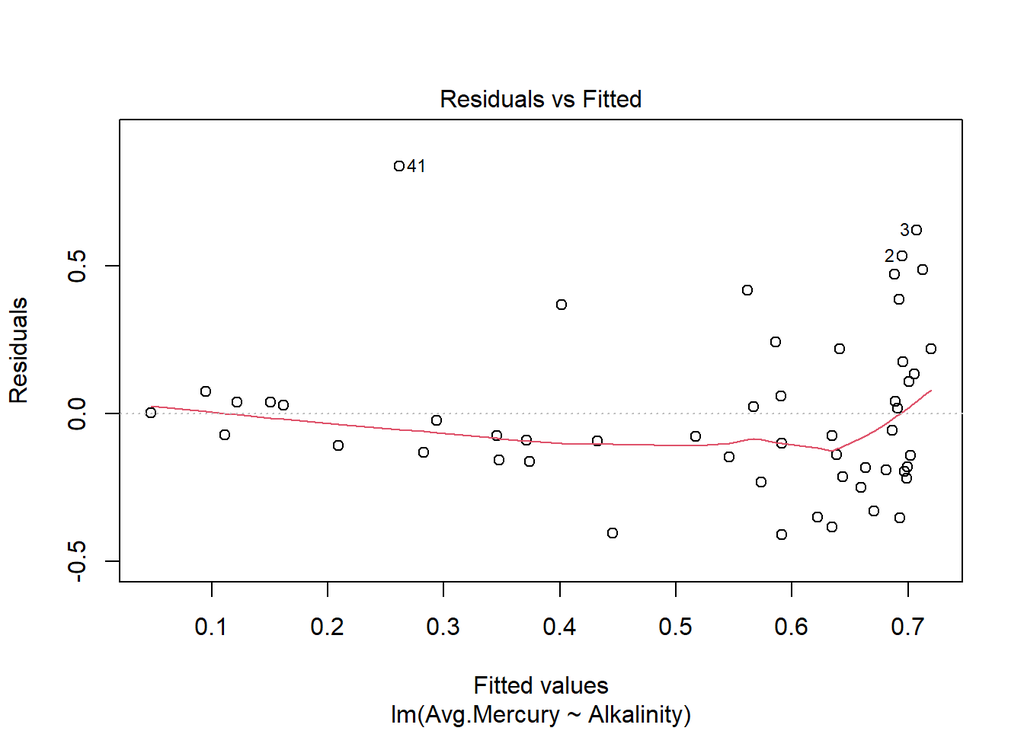

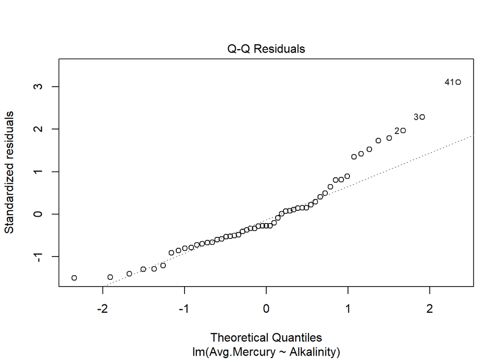

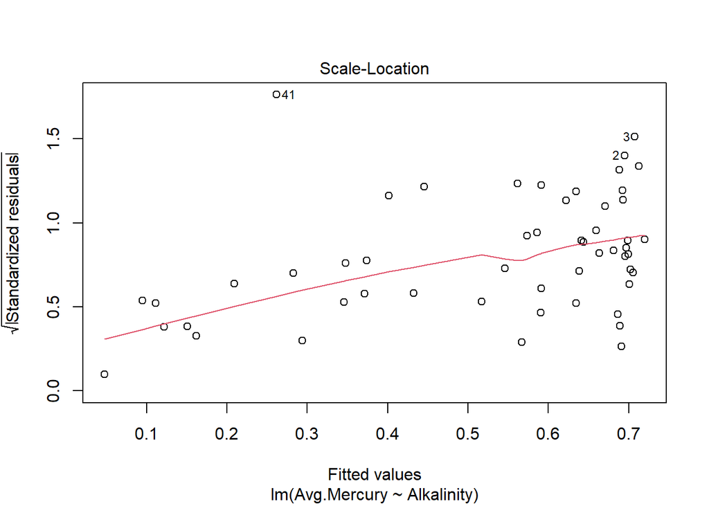

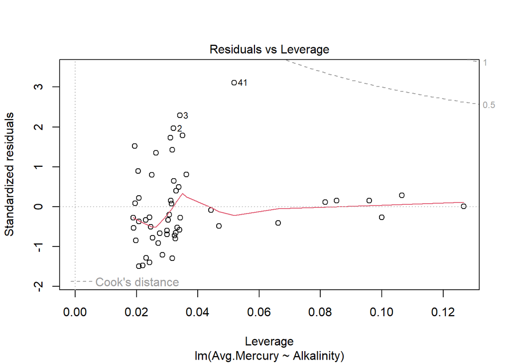

```r
plot(model)
```

- The residulas/fitted shows a curved pattern suggesting that the linear model is not appropriate for the data.

- Points on the qq plot on the do not exihibit a straight line meaning the data violates the assumptions of normal distribution.
4. Use a log-transformation on one or both of the variables to see if the model in a. can be improved.

```r
mercury$LogAvgMercury <- log(mercury$Avg.Mercury)

mercury$LogAlkalinity <- log(mercury$Alkalinity)

# model 2 log mercury and log alkalinity
model2 <- lm(LogAvgMercury ~ LogAlkalinity,
             data = mercury)

summary(model2)
```

```
##
## Call:
## lm(formula = LogAvgMercury ~ LogAlkalinity, data = mercury)
##
## Residuals:
##      Min       1Q   Median       3Q      Max
## -1.84974 -0.37786  0.02178  0.30768  1.70226
##
## Coefficients:
##               Estimate Std. Error t value Pr(>|t|)
## (Intercept)    0.50987    0.22609   2.255   0.0284 *
## LogAlkalinity -0.47327    0.06988  -6.773 1.25e-08 ***
## ---
## Signif. codes:  0 '***' 0.001 '**' 0.01 '*' 0.05 '.' 0.1 ' ' 1
##
## Residual standard error: 0.6151 on 51 degrees of freedom
## Multiple R-squared:  0.4735, Adjusted R-squared:  0.4632
## F-statistic: 45.87 on 1 and 51 DF,  p-value: 1.245e-08
```

```r
# model 3 log mercury and alkalinity
model3 <- lm(LogAvgMercury ~ Alkalinity,
             data = mercury)
summary(model3)
```

```
##
## Call:
## lm(formula = LogAvgMercury ~ Alkalinity, data = mercury)
##
## Residuals:
##      Min       1Q   Median       3Q      Max
## -2.06553 -0.27948  0.08225  0.29231  1.79197
##
## Coefficients:
##              Estimate Std. Error t value Pr(>|t|)
## (Intercept) -0.321099   0.114715  -2.799  0.00722 **
## Alkalinity  -0.015703   0.002152  -7.295 1.86e-09 ***
## ---
## Signif. codes:  0 '***' 0.001 '**' 0.01 '*' 0.05 '.' 0.1 ' ' 1
##
## Residual standard error: 0.593 on 51 degrees of freedom
## Multiple R-squared:  0.5107, Adjusted R-squared:  0.5011
## F-statistic: 53.22 on 1 and 51 DF,  p-value: 1.859e-09
```

```r
# model 4 avg mercury and log alkalinity
model4 <- lm(Avg.Mercury ~ LogAlkalinity,
             data = mercury)
summary(model4)
```

```
##
## Call:
## lm(formula = Avg.Mercury ~ LogAlkalinity, data = mercury)
##
## Residuals:
##      Min       1Q   Median       3Q      Max
## -0.39868 -0.14459 -0.03295  0.03544  0.84106
##
## Coefficients:
##               Estimate Std. Error t value Pr(>|t|)
## (Intercept)    1.07412    0.09595  11.195 2.39e-15 ***
## LogAlkalinity -0.18225    0.02965  -6.146 1.21e-07 ***
## ---
## Signif. codes:  0 '***' 0.001 '**' 0.01 '*' 0.05 '.' 0.1 ' ' 1
##
## Residual standard error: 0.261 on 51 degrees of freedom
## Multiple R-squared:  0.4255, Adjusted R-squared:  0.4142
## F-statistic: 37.77 on 1 and 51 DF,  p-value: 1.211e-07
```

```r
AIC(model, model2, model3, model4)
```

```
##        df       AIC
## model   3  18.31329
## model2  3 102.85050
## model3  3  98.97092
## model4  3  11.99184
```

```r
BIC(model, model2, model3, model4)
```

```
##        df       BIC
## model   3  24.22417
## model2  3 108.76137
## model3  3 104.88179
## model4  3  17.90271
```

5. Discuss the “best” fitting model (including why you think it’s the best).

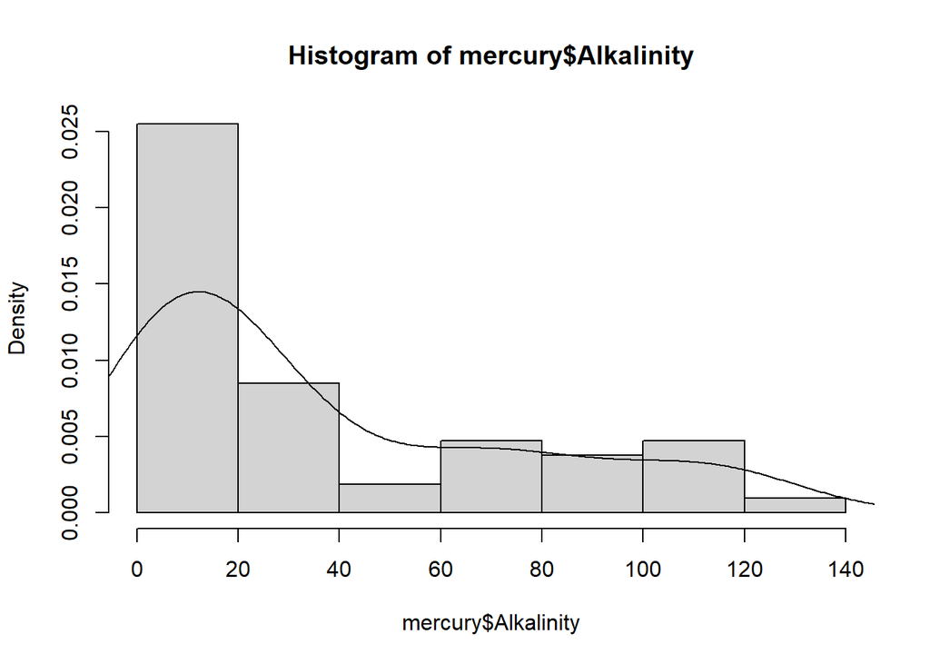

```r
hist(mercury$Alkalinity, prob = TRUE)
lines(density(mercury$Alkalinity))
```

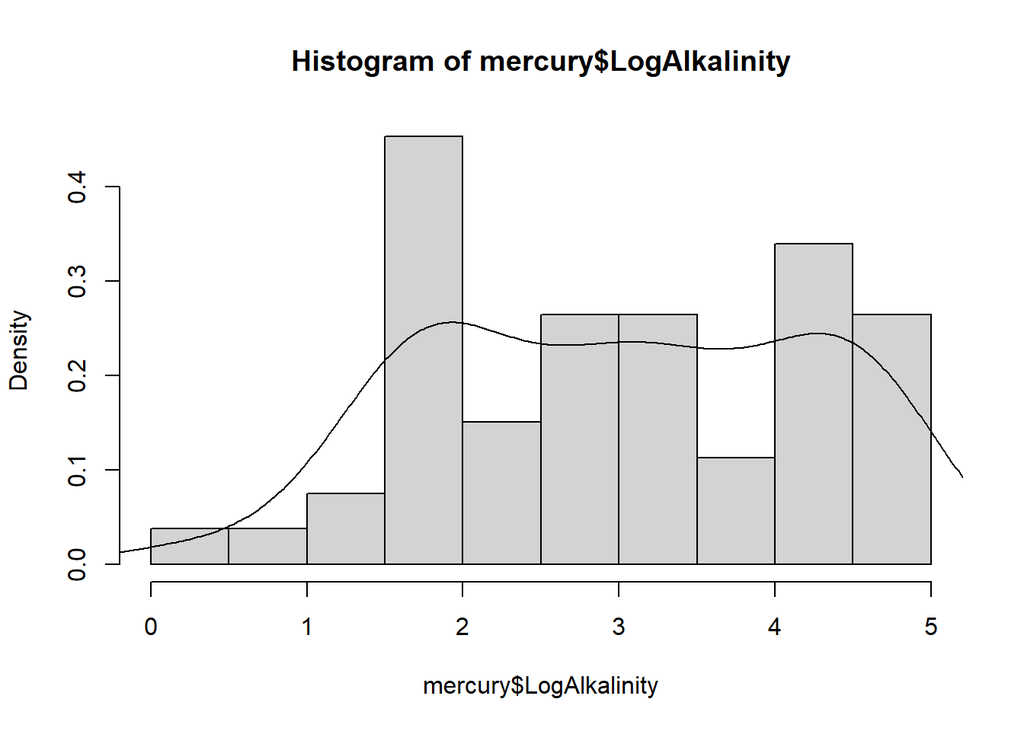

```r
hist(mercury$LogAlkalinity, prob = TRUE)
lines(density(mercury$LogAlkalinity))
```

6. Interpret the slope of your chosen model and provide a 95% confidence interval for it

```r
coef(model4)
```

```
##   (Intercept) LogAlkalinity
##     1.0741247    -0.1822547
```

```r
confint(model4, level = 0.95)
```

```
##                    2.5 %     97.5 %
## (Intercept)    0.8815042  1.2667453
## LogAlkalinity -0.2417895 -0.1227199
```